# Practical Machine Learning Assignment

Rhys Tutt

26 September 2017

## Data Import and Clean-Up

Import the datasets and review the data to make some initial observations.

```r
setwd("C:\\Users\\RTutt\\Desktop\\Practical Machine Learning\\Assignment")
TrainingDataset <- read.csv("pml-training.csv", na.strings=c("","#DIV/0!","NA"), header=TRUE)
TestingDataset <- read.csv("pml-testing.csv", na.strings=c("","#DIV/0!","NA"), header=TRUE)

dim(TrainingDataset)
```

```
## [1] 19622   160
```

```r
dim(TestingDataset)
```

```
## [1]  20 160
```

```r
str(TrainingDataset, list.len = 20)
```

```
## 'data.frame':    19622 obs. of  160 variables:
##  $ X                       : int  1 2 3 4 5 6 7 8 9 10 ...
##  $ user_name               : Factor w/ 6 levels "adelmo","carlitos",..: 2 2 2 2 2 2 2 2 2 2 ...
##  $ raw_timestamp_part_1    : int  1323084231 1323084231 1323084231 1323084232 1323084232 1323084232 1323084232 1323084232 1323084232 1323084232 ...
##  $ raw_timestamp_part_2    : int  788290 808298 820366 120339 196328 304277 368296 440390 484323 484434 ...
##  $ cvtd_timestamp          : Factor w/ 20 levels "02/12/2011 13:32",..: 9 9 9 9 9 9 9 9 9 9 ...
##  $ new_window              : Factor w/ 2 levels "no","yes": 1 1 1 1 1 1 1 1 1 1 ...
##  $ num_window              : int  11 11 11 12 12 12 12 12 12 12 ...
##  $ roll_belt               : num  1.41 1.41 1.42 1.48 1.48 1.45 1.42 1.42 1.43 1.45 ...
##  $ pitch_belt              : num  8.07 8.07 8.07 8.05 8.07 8.06 8.09 8.13 8.16 8.17 ...
##  $ yaw_belt                : num  -94.4 -94.4 -94.4 -94.4 -94.4 -94.4 -94.4 -94.4 -94.4 -94.4 ...
##  $ total_accel_belt        : int  3 3 3 3 3 3 3 3 3 3 ...
##  $ kurtosis_roll_belt      : num  NA NA NA NA NA NA NA NA NA NA ...
##  $ kurtosis_picth_belt     : num  NA NA NA NA NA NA NA NA NA NA ...
##  $ kurtosis_yaw_belt       : logi  NA NA NA NA NA NA ...
##  $ skewness_roll_belt      : num  NA NA NA NA NA NA NA NA NA NA ...
##  $ skewness_roll_belt.1    : num  NA NA NA NA NA NA NA NA NA NA ...
##  $ skewness_yaw_belt       : logi  NA NA NA NA NA NA ...
##  $ max_roll_belt           : num  NA NA NA NA NA NA NA NA NA NA ...
##  $ max_picth_belt          : int  NA NA NA NA NA NA NA NA NA NA ...
##  $ max_yaw_belt            : num  NA NA NA NA NA NA NA NA NA NA ...
##   [list output truncated]
```

There were “#DIV/0!” values visible, so I went back and assigned these to be NA strings upon importing the datasets. Can also see there are a lot of columns with NA and missing values, so these will need to be cleaned up using the colSums and is.na functions.

```r
set.seed(123)
TrainingDataset <- TrainingDataset[,colSums(is.na(TrainingDataset)) == 0]
TestingDataset <- TestingDataset[,colSums(is.na(TestingDataset)) == 0]
```

Next I’ll review the data for any near zero variables, which shows there is one variable to be removed “new_window”.

```r
nzv <- nearZeroVar(TrainingDataset, saveMetrics = TRUE)
nzv[nzv$nzv == TRUE,]
```

```
##            freqRatio percentUnique zeroVar  nzv
## new_window  47.33005    0.01019264   FALSE TRUE
```

```r
TrainingDataset$new_window <- NULL
TestingDataset$new_window <- NULL
```

Also observed certain variables which contain user information that won’t have any effect on the outcome so these are being removed.

```r
TrainingDataset <- TrainingDataset[, 6:59]
TestingDataset <- TestingDataset[, 6:59]
```

## Splitting The Dataset

Although we have already assigned a Training and Testing dataset, I’ll now split the Training dataset further for training and validation. This is because we want to train the model on the training set, then test the accuracy on the validation set to predict the out of sample error rate and choose the best model. Then once I’ve picked the most appropriate model this will be used once to make predictions on the test set.

```r
inTrain <- createDataPartition(y = TrainingDataset$classe,
                               p = 0.7, list = FALSE)

training <- TrainingDataset[inTrain,]
validating <- TrainingDataset[-inTrain,]
```

## Feature Selection and PCA

As there are quite a lot of variables I’m going to use Caret’s rfeControl function to reduce this number to the top 15 which predict the most variance. This in turn will reduce noise and make the model more interpretable.

```r
ctrl <- rfeControl(functions = rfFuncs,
                   method = "cv",
                   repeats = 0,
                   verbose = FALSE)

results <- rfe(x = training[,-54], y = training[,54],
                 sizes = 15,
                 rfeControl = ctrl)

predictors(results)
```

```
##  [1] "num_window"        "roll_belt"         "yaw_belt"
##  [4] "magnet_dumbbell_z" "pitch_belt"        "magnet_dumbbell_y"
##  [7] "pitch_forearm"     "accel_dumbbell_y"  "roll_dumbbell"
## [10] "magnet_dumbbell_x" "accel_dumbbell_z"  "roll_arm"
## [13] "roll_forearm"      "magnet_forearm_z"  "magnet_belt_z"
```

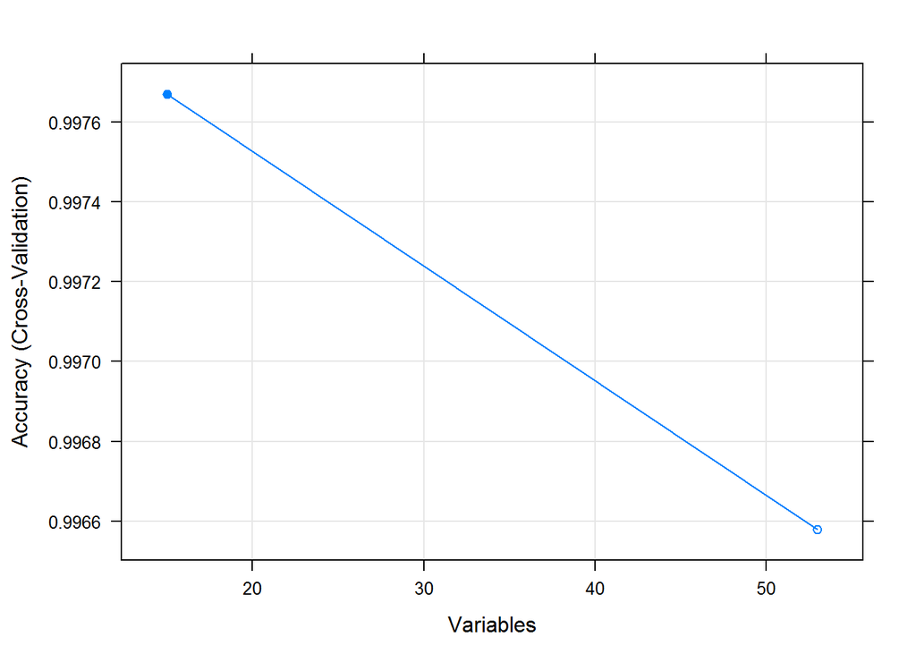

```r
plot(results, type=c("g", "o"))
```

Although it’s only a small amount, as seen from the plot, the model only becomes less accurate with additional variables. As such, I’m Only keeping these above 15 predictors remaining in the datasets for the model predictions.

```r
training <- training[,c("num_window","roll_belt","yaw_belt","magnet_dumbbell_z","pitch_belt","magnet_dumbbell_y","pitch_forearm","accel_dumbbell_y","roll_dumbbell","magnet_dumbbell_x","accel_dumbbell_z","roll_arm","roll_forearm","magnet_forearm_z","magnet_belt_z","classe")]
validating <- validating[,c("num_window","roll_belt","yaw_belt","magnet_dumbbell_z","pitch_belt","magnet_dumbbell_y","pitch_forearm","accel_dumbbell_y","roll_dumbbell","magnet_dumbbell_x","accel_dumbbell_z","roll_arm","roll_forearm","magnet_forearm_z","magnet_belt_z","classe")]
TestingDataset <- TestingDataset[,c("num_window","roll_belt","yaw_belt","magnet_dumbbell_z","pitch_belt","magnet_dumbbell_y","pitch_forearm","accel_dumbbell_y","roll_dumbbell","magnet_dumbbell_x","accel_dumbbell_z","roll_arm","roll_forearm","magnet_forearm_z","magnet_belt_z","problem_id")]
```

The last step before building the model is now reviewing the predictors to see if any are highly correlated. First I’ve removed those with a correlation of 1 as these are just referring to themselves and then using the threshold of 80% to define high correlation.

```r
corr <- abs(cor(training[,c("num_window","roll_belt","yaw_belt","magnet_dumbbell_z","pitch_belt","magnet_dumbbell_y","pitch_forearm","roll_dumbbell","magnet_dumbbell_x","accel_dumbbell_z","roll_arm","roll_forearm","magnet_forearm_z","magnet_belt_z")]))
diag(corr) <- 0
which(corr > 0.8, arr.ind = TRUE)
```

```
##           row col
## yaw_belt    3   2
## roll_belt   2   3
```

It is evident that “yaw_belt” and “roll_belt” are highly correlated so will perform PCA on them to combine them into one predictor, then adjust all the datasets and re-order the variables.

```r
pca <- preProcess(x = training[,c("yaw_belt","roll_belt")],
                  method = "pca",
                  pcaComp = 1)

training <- predict(pca, training)
validating <- predict(pca, validating)
TestingDataset <- predict(pca, TestingDataset)

training <- training[,c(1,2,3,4,5,6,7,8,9,10,11,12,13,15,14)]
validating <- validating[,c(1,2,3,4,5,6,7,8,9,10,11,12,13,15,14)]
```

## Random Forest Model

Build a Random Forest model.

```r
modrf <- randomForest(classe ~ ., data = training, ntree = 50, prox=TRUE)
print(modrf)
```

```
##
## Call:
##  randomForest(formula = classe ~ ., data = training, ntree = 50,      prox = TRUE)
##                Type of random forest: classification
##                      Number of trees: 50
## No. of variables tried at each split: 3
##
##         OOB estimate of  error rate: 0.35%
## Confusion matrix:
##      A    B    C    D    E  class.error
## A 3905    0    0    0    1 0.0002560164
## B    4 2645    7    2    0 0.0048908954
## C    0    7 2387    1    1 0.0037562604
## D    0    0   14 2238    0 0.0062166963
## E    0    1    1    9 2514 0.0043564356
```

## GBM Model

Build a gradient boosted model using Caret’s train function.

```r
modgbm <- train(data = training, classe ~ ., method = "gbm", verbose = FALSE)
print(modgbm)
```

```
## Stochastic Gradient Boosting
##
## 13737 samples
##    14 predictor
##     5 classes: 'A', 'B', 'C', 'D', 'E'
##
## No pre-processing
## Resampling: Bootstrapped (25 reps)
## Summary of sample sizes: 13737, 13737, 13737, 13737, 13737, 13737, ...
## Resampling results across tuning parameters:
##
##   interaction.depth  n.trees  Accuracy   Kappa
##   1                   50      0.7118644  0.6338165
##   1                  100      0.7908742  0.7353234
##   1                  150      0.8380336  0.7953082
##   2                   50      0.8728833  0.8391323
##   2                  100      0.9441882  0.9293893
##   2                  150      0.9704501  0.9626204
##   3                   50      0.9328464  0.9150380
##   3                  100      0.9765310  0.9703123
##   3                  150      0.9894542  0.9866628
##
## Tuning parameter 'shrinkage' was held constant at a value of 0.1
##
## Tuning parameter 'n.minobsinnode' was held constant at a value of 10
## Accuracy was used to select the optimal model using  the largest value.
## The final values used for the model were n.trees = 150,
##  interaction.depth = 3, shrinkage = 0.1 and n.minobsinnode = 10.
```

## Evaluating Models

Make predictions from both models on the validation sets and then analyse these using Confusion Matrixes.

The accuracy of the Random Forest model is 99.73% with an out-of-sample error rate of 0.27%. The accuracy of the gbm model is 99.27%, so the out of sample error is 0.73%. From these results it is evident that the Random Forest model is the best selection to predict on the test set.

```r
predrf <- predict(modrf, validating)
predgbm <- predict(modgbm, validating)

confusionMatrix(predrf, validating$classe)
```

```
## Confusion Matrix and Statistics
##
##           Reference
## Prediction    A    B    C    D    E
##          A 1674    1    0    0    0
##          B    0 1137    8    0    1
##          C    0    0 1018    4    0
##          D    0    1    0  959    0
##          E    0    0    0    1 1081
##
## Overall Statistics
##
##                Accuracy : 0.9973
##                  95% CI : (0.9956, 0.9984)
##     No Information Rate : 0.2845
##     P-Value [Acc > NIR] : < 2.2e-16
##
##                   Kappa : 0.9966
##  Mcnemar's Test P-Value : NA
##
## Statistics by Class:
##
##                      Class: A Class: B Class: C Class: D Class: E
## Sensitivity            1.0000   0.9982   0.9922   0.9948   0.9991
## Specificity            0.9998   0.9981   0.9992   0.9998   0.9998
## Pos Pred Value         0.9994   0.9921   0.9961   0.9990   0.9991
## Neg Pred Value         1.0000   0.9996   0.9984   0.9990   0.9998
## Prevalence             0.2845   0.1935   0.1743   0.1638   0.1839
## Detection Rate         0.2845   0.1932   0.1730   0.1630   0.1837
## Detection Prevalence   0.2846   0.1947   0.1737   0.1631   0.1839
## Balanced Accuracy      0.9999   0.9982   0.9957   0.9973   0.9994
```

```r
confusionMatrix(predgbm, validating$classe)
```

```
## Confusion Matrix and Statistics
##
##           Reference
## Prediction    A    B    C    D    E
##          A 1674    1    0    0    0
##          B    0 1131    4    0    1
##          C    0    7 1016   13    5
##          D    0    0    6  951    6
##          E    0    0    0    0 1070
##
## Overall Statistics
##
##                Accuracy : 0.9927
##                  95% CI : (0.9902, 0.9947)
##     No Information Rate : 0.2845
##     P-Value [Acc > NIR] : < 2.2e-16
##
##                   Kappa : 0.9908
##  Mcnemar's Test P-Value : NA
##
## Statistics by Class:
##
##                      Class: A Class: B Class: C Class: D Class: E
## Sensitivity            1.0000   0.9930   0.9903   0.9865   0.9889
## Specificity            0.9998   0.9989   0.9949   0.9976   1.0000
## Pos Pred Value         0.9994   0.9956   0.9760   0.9875   1.0000
## Neg Pred Value         1.0000   0.9983   0.9979   0.9974   0.9975
## Prevalence             0.2845   0.1935   0.1743   0.1638   0.1839
## Detection Rate         0.2845   0.1922   0.1726   0.1616   0.1818
## Detection Prevalence   0.2846   0.1930   0.1769   0.1636   0.1818
## Balanced Accuracy      0.9999   0.9960   0.9926   0.9920   0.9945
```

## Final Predictions on Test Set

```r
finalpred <- predict(modrf, TestingDataset)

data.frame(TestingDataset$problem_id, finalpred)
```

```
##    TestingDataset.problem_id finalpred
## 1                          1         B
## 2                          2         A
## 3                          3         B
## 4                          4         A
## 5                          5         A
## 6                          6         E
## 7                          7         D
## 8                          8         B
## 9                          9         A
## 10                        10         A
## 11                        11         B
## 12                        12         C
## 13                        13         B
## 14                        14         A
## 15                        15         E
## 16                        16         E
## 17                        17         A
## 18                        18         B
## 19                        19         B
## 20                        20         B
```